# 这

# 章节

# C H A P T E R

# 14

# 14

# 永动机

# Perpetual Motion

1983 年 1 月 2 日

January 2, 1983

“是的，这就是他，”我说。

"Yes, this is he," I said.

“我们希望你作为麻省理工学院的参赛者之一前往加州参加 1 月 20 日的永动机竞赛，”制片人说道。“我们收到了 30 份申请这三个地点的申请，Chedd Angier Productions 的每个人都同意在未亲眼见过的情况下接受您。您的申请真是大胆。”

"We'd like you to go to California as one of MIT's contestants in the perpetual motion machine contest on January 20," the producer said. "We received thirty applications for the three spots, and everyone here at Chedd Angier Productions agreed to accept you sight unseen. Your application had real chutzpah."

耶皮。免费加州之旅。全国范围内的电视曝光是任何一个苦苦挣扎的年轻喜剧演员都会拼命追求的。如果我打得好，去参加有氧运动课，在接下来的两周里进行一些训练，并参加魅力课程，也许一些纽约或好莱坞的制片人会看到这个节目并说，这孩子太棒了。让我们给他报名一部乏味的情景喜剧吧。”每集 30K 的收入肯定比工程师每年 3 万美元的收入要高。

Yippee. A free trip to California. Nationwide television exposure that any struggling young comic would kill for. If I play my cards right, go to aerobics class, pump some iron for the next two weeks, and take charisma lessons, maybe some New York or Hollywood producer will see the show and say, This kid's great. Let's sign him up for a vapid sitcom." Thirty K per episode sure beats an engineer's $30K per year.

“非常感谢。其他类似的应用程序是什么让我的应用程序如此脱颖而出？”

"Thanks a lot. What were the other applications like that made mine stand out so much?"

"Most of the others submitted six-page notarized essays on perpetual motion, with figures and drawings, and reference letters from professors. They all looked the same after a while. But yours stood out. We've also selected two others on the basis of our interviews. One of them came to the interview wearing a tuxedo and a red carnation. He's quite an accomplished trombone player."

“这听起来像是朋友的朋友，我每隔一两个月就在无限走廊里聊天的一个人。是丹·瓦格纳吗？”

"That sounds like a friend of a friend, a guy I chat with in the infinite corridor every month or two. Is it Dan Wagner?"

“是的，就是他。另一位是机械工程专业的大四学生蒂姆·纽伯格。他非常聪明。我选择他是因为他说他最有趣的智力经历就是阅读塔木德。我想你们三个将成为一支优秀的团队。”

"Yes, that's him. And the other one is a senior in Mechanical Engineering, Tim Neuberger. He's extremely bright. I picked him because he said the most interesting intellectual experience he'd had was reading the Talmud. I think the three of you will make a good team."

1 月 3 日

January 3

文献综述。永动机。我参考了 Gyftopoulos 课堂上的笔记本。问题集 3，问题 1：“证明第一类永动机 (IPMM1)-4 的不可能性，满分 10 分。” 问题 2：“证明第二类永动机 (IPMM2)-2 的不可能性，满分 10 分。” 这些都没有帮助。我记得我曾问过吉夫托普洛斯教授，放在一杯水旁边的玩具鸟是否符合永动机的条件。当它的喙进入水中时，水进入喙上的灯芯，通过毛细管作用将其向下拉。然后它来回摇晃，似乎没有能量输入。

Literature review. Perpetual Motion. I referred to my notebook from Gyftopoulos's class. Problem set 3, Problem 1: "Prove the Impossibility of a Perpetual Motion Machine of the First Kind (IPMM1)-4 out of 10 points." Problem 2: "Prove the Impossibility of a Perpetual Motion Machine of the Second Kind (IPMM2)-2 out of 10 points." These will be no help. I remembered asking Professor Gyftopoulos whether the toy bird that you put next to a glass of water would qualify as a perpetual motion machine. When its beak goes into the water it's pulled down by the capillary action of the water going into the wick on the beak. Then it rocks back and forth, with seemingly no energy input.

是的，吉夫托普洛斯教授说过，你说得对，这不是永动机，因为你有永动机，但没有将能量转移到系统之外。

Yes, Professor Gyftopoulos had said, you are right in saying that is not a perpetual motion machine, because you have perpetual motion but no transfer of energy out of the system.

我们还没有见过永动机，这种机器发出的能量比输入的能量多。因为我们还没有见过 PMM，所以我们会说 PMM 不可能存在，因为能量，无论是什么，都是守恒的。由于能量守恒，因此不可能有第一类永动机。

We haven't seen a perpetual motion machine, something that puts out more energy than goes into it. Since we haven't seen a PMM, we'll say that one can't exist, because energy, whatever that is, is conserved. Since energy is conserved, there can be no perpetual motion machines of the first kind.

永动机不断地提供动力，无需能量输入。第一种 PMM“旨在从下落或转动的物体传递比将设备恢复到原始状态所需的更多的能量”。一个例子是连接在一起的闭环水车和泵。

A perpetual motion machine delivers power perpetually, with no energy input. A PMM of the first kind "purports to deliver more energy from a falling or turning body than is required to restore the device to its original state." An example of this is a closedloop waterwheel and pump joined together.

如果水车产生的功率大于泵将水推回水车顶部所需的功率，则水车可以在没有任何燃料的情况下永久发电。但尽管进行了多次尝试，仍然没有人设计出一种能够实现这一目标的系统。如果他们有的话，波斯湾只不过是一个令人愉快的度假胜地。

If the waterwheel generated more power than the pump needed to push the water back up to the top of the waterwheel, the waterwheel could generate power perpetually without any fuel. But despite many attempts, no one has devised a system that achieves that. If they had, the Persian Gulf would be no more than a pleasant vacation spot.

大英百科全书上的一篇文章描述了永动机的各种尝试：伍斯特第二侯爵爱德华·萨默塞特（1601-1667 年）在 1638 年或 1639 年左右制造了一台机器，并为查理一世和他的宫廷操作了该装置。在同一世纪，荷兰物理学家 WJ Gravesand 检查了法国人 Offyreus 的机器，并对它的结构印象深刻，尽管他不被允许检查机器的内部。格雷夫桑在给牛顿的一封冗长而详细的信中描述了该装置。

An article in Encyclopaedia Britannica describes the various attempts at perpetual motion: Edward Somerset, second marquis of Worcester (1601-1667), produced a machine around 1638 or 1639 and operated the device for Charles I and his court. In the same century, the Dutch physicist W. J. Gravesand inspected the machine of the Frenchman Offyreus and was impressed by its construction, although he was not allowed to inspect the interior of the machine. Gravesand wrote about the device in a lengthy and detailed letter to Newton.

与我们今天的高科技设备相比，百科全书中的简单图纸看起来很原始，但它们看起来和许多两七十台设计竞赛机器一样复杂，包括我自己的。

The simple drawings in the encyclopaedia looked primitive compared to our high-technology devices today, but they looked just as sophisticated as many of the two-seventy design contest machines, including my own.

1 月 4 日

January 4

我请求 Chet Yeung 允许我请假去参加比赛，再加上一周的假期时间去湾区骑自行车，为镜头减掉一些体重。

I asked Chet Yeung for permission to take the time off to go to the contest, plus a week of vacation time to bicycle in the Bay Area, to lose some weight for the cameras.

他突然问道：“他们为什么选你？”

He asked abruptly, "Why'd they pick you?"

“哎呀，切特，我不知道；也许他们希望团队中有人让其他两个人看起来很聪明。”

"Gee, Chet, I don't know; maybe they wanted somebody on the team to make the other two guys look smart."

“是的，好吧，我想你可以休息一下。不过，我应该继续这样做。如果他们真的想要一个团队来解决这个问题，他们就会有像我这样的人，”切特说。

"Yeah, well, I guess you can have the time off. I should go along on that, though. If they really wanted to have a team that would solve it, they'd have someone like me along," Chet said.

我想知道他是否冒充研究生并在团队选拔时将自己的名字写在帽子上。我回答说：“他们只想要学生来做这件事。好吧，我知道你看起来很年轻，适合当学生，但你会有不公平的优势。你很有天赋。”

I wondered whether he'd posed as a graduate student and put his name in the hat for the team selection. I answered, "They only want students on this thing. Okay, I know you look young enough to be a student, but you'd have an unfair advantage. You're gifted."

“是的，好吧，只是尽量不要因为你在电视上说的话让研究所难堪，”切特说。“让其他人来说话吧。”

"Yeah, well, just try not to embarrass the institute by what you say on TV," Chet said. "Let the other guys do most of the talking."

谢谢你，切特，投下信任票。

Thank you, Chet, for that vote of confidence.

“哦，是的，但在你走之前，我希望你对我组装的计算机模型进行一些运行，以确保 RCM 模拟真实柴油发动机的冲程。我认为在我们之前研究机器的人可能会弄乱了不压井室的组装，”切特说。

"Oh yeah, but before you go I want you to do some runs of a computer model I've put together to make sure the RCM simulates the stroke of a real diesel engine. I think the guys who worked on the machine before us may have messed up the assembly of the snubbing chamber," Chet said.

我离开他的办公室，去找吉夫托普洛斯教授交谈，向他索要永动机的参考资料。

I left his office and went to talk to Professor Gyftopoulos, to ask him for reference materials on perpetual motion machines.

“这非常有趣。我想知道他们为什么选择你，”他说。

"That's very interesting. I wonder why they picked you," he said.

“他们喜欢我的申请。”

"They liked my application."

“好吧，寻找机器中可能发生不可逆性的地方。机器内部肯定会有摩擦，并且机器内部肯定会有能量供应。尽你所能找到这些地方。”

"Well, look for places where irreversibility may occur in the machine. There will certainly be friction, and there will certainly be an energy supply within the machine. Do what you can to locate these."

格林的态度更加积极一些。“恭喜，”他说。“被选为麻省理工学院的代表，真是一种荣幸。”

Greene was a little more positive. "Congratulations," he said. "That's quite an honor, being picked as a representative from MIT. "

我很高兴有人这么认为。

I'm glad somebody thinks so.

“不过，你会面临来自伯克利的激烈竞争。但这是一个可爱的地区。我希望你能给自己时间去欣赏一些景点。”

"You'll have some tough competition from Berkeley, though. But it's a lovely area. I hope you're giving yourself time to take in a few of the sights."

“是的，我会在那里骑一周左右。对于如何思考这个问题，你有什么建议吗？”

"Yes, I'll cycle there for about a week. Do you have any suggestions as to how to think about the problem?"

“是的，好吧，寻找能量质量下降的地方。多年来对永动机的大多数尝试都包括从过程中移除能量的部分以及将能量重新投入到过程中的其他部分。问题是，在现实生活中，只要有能量流动，熵就会增加。你可以通过骑自行车的例子记住这一点。”

"Yes, well, look for where there is degradation in the quality of the energy. Most of the attempts at perpetual motion machines over the ages have included sections where energy is removed from the process and other sections where it's put back into the process. The problem is that wherever you have energy flow, in real life you have entropy increase. You remember that with your cycling example."

“谢谢你的帮助，先生，”我说。“演出开始时我会通知你。”

"Thanks for your help, sir," I said. "I'll let you know when the show is on."

1月6日

January 6

更多盐矿。Chet 向我展示了他的 RCM 活塞运动模型，并在实验室的数字（Ken Olsen，'50）VAX 计算机上复制了该程序。切特在一张绿白相间的电脑纸上为我重新绘制了机器。

More salt mines. Chet showed me his model for the motion of the piston of the RCM and made a copy of the program on the lab's Digital (Ken Olsen, '50) VAX computer. Chet redrew the machine for me on a piece of green and white computer paper.

“所以你看，对轴的运动进行建模的想法是编写运动轴的牛顿第二定律；在其运动的每一点，轴上的力的总和将等于轴组件的质量乘以它的质量。那一刻的加速度，”他说。“我们从油箱获得驱动气压，然后我们获得气缸中气体的压力，推动燃烧室的活塞，然后我们得到后活塞的拖动并减慢整个过程，具体取决于如何那里有很大的空间。”

"So you see, the idea in modeling the motion of the shaft is to write Newton's second law for the moving shaft; at every point in its motion, the sum of the forces on the shaft will equal the mass of the shaft assembly times its acceleration at that moment," he said. "We got the driving air pressure from the tank, and then we got the pressure of the gas in the cylinder pushing back on the combustion chamber's piston, and then we got the back piston dragging along and slowing the whole thing down, depending on how much space there is."

我记得格林的气球问题，我是如何让气球朝一个方向膨胀的。

I remembered Greene's balloon problem, how I'd made the balloon expand in just one direction.

然后我又看了一遍RCM图，并将其翻译成模型的语言。

Then I looked at the RCM diagram again and translated it into the language of the model.

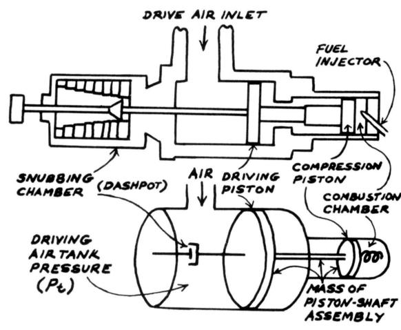

切特继续说道，“所以我希望你把机器从后面拆开，确定可用的环几何形状和带压作业活塞直径。然后我希望你改变计算机中环的顺序，直到机器向前运动。该轴与真实发动机中的轴运动相匹配。”

Chet continued, "So what I want you to do is take the machine apart in the back and determine the ring geometries available and the snubbing piston diameter. Then I want you to change the order of the rings in the computer until the forward motion of the shaft matches the motion of the shaft in a real engine."

我想知道压缩曲线的发生方式为何或是否会产生很大差异，或者切特的观点是否是，这是我们可以控制的东西，使实验更好地匹配现实生活，因此更有用，当我们在底特律发表论文时，问题更少，所以我们必须这样做。可以办到; 因此，我们这样做。但这里还有另一个教训值得吸取。

I wondered why or whether it made much difference how the compression profile took place or whether Chet's point was, This is something we can control to make the experiment match real life better and therefore more useful, less questionable when we present a paper in Detroit, so we have to do it. It can be done; therefore, we do it. But there was another lesson to be learned here.

我的任务是拆开机器，获取无心盘的尺寸，将尺寸输入计算机，并调整无心盘的顺序，直到活塞按要求穿过它们，所有这些都在计算机上进行。另一种选择是反复试验，即将机器拆开并再次组装起来并进行测试，直到获得相同的结果。

My task was to take the machine apart, take the dimensions of the centerless disks, input the dimensions in the computer, and play with the order of the centerless disks until the piston moved through them as required, all on the computer. The alternative was trial and error-i.e., take the machine apart and put it together again and test it until we achieved the same result.

切特已经设置了程序，所以我只需输入环直径列表，然后看看会发生什么。我在一小时内将 RCM 拆开并重新组装了十次，只需更改计算机输入语句中环直径的顺序即可。在现实世界中，工程师一直在做这种事情，因为付钱给工程师建立计算机模型并对其进行破解比付钱给机械师破解金属块要便宜得多。

Chet had set up the program so I only had to input a list of the ring diameters and see what happened. I took the RCM apart and put it back together ten times in an hour, just by changing the order of the ring diameters in the computer's input statement. In the real world, engineers do this kind of thing all the time because it is much cheaper to pay an engineer to set up a computer model and hack away at it than to pay a machinist to hack away at blocks of metal.

那个星期五我又花了几个小时，但没有取得任何进展。周一早上，切特说：“别担心这个问题；我周末就完成了。”

I hacked for a few more hours that Friday but I made no progress. On Monday morning Chet said, "Don't worry about that problem; I finished it over the weekend."

“为什么，切特？” 我问。“我以为那是我的工作。你让我开始，为什么不让我完成呢？”

"Why, Chet?" I asked. "I thought that was my job. You let me start it; why didn't you let me finish it?"

“我不想让你在这上面浪费更多的时间。我们必须在三月份的联盟会议之前把机器重新组装起来并进行一些点火。在你休息一周和下学期即将到来的情况下，我们必须取得很大的进展一月份，”他回答道。

"I didn't want you to waste any more time on it. We gotta put the machine back together and do some firings before the consortium meeting in March. What with your week off and the next semester coming up we gotta make a lotta progress in January," he answered.

这就是切特的风格。微观管理者。切特在让我当学生的问题上陷入了进退两难的境地。一方面，我做这个实验的目的是为了接受工程师的培训。另一方面，也许更重要的是，我从事实验的目的是获得结果、发表论文、晋升切特为正教授，并保留赞助商的收入来源。

This was Chet's style. The micromanager. Chet was stuck between a rock and a hard place in having me as a student. On the one hand, the point of my working on the experiment was for me to be trained as an engineer. On the other, perhaps more significant, hand, the point of my working on the experiment was to obtain results, publish papers, promote Chet to full professorship, and retain the sponsors' income stream.

因此，当我以笨拙的方式做事花了太长时间，因为我以前没有做过这些事情，而且我的思维处理不像切特那样精简和刻薄时，他会介入并帮助我。或者有时，比如周末，他会亲自参与并完成任务。

So when in my lumbering way I took too long to do things because I hadn't done them before and my thought processing wasn't as lean and mean as Chet's, he'd step in and help me. Or sometimes, like over the weekend, he'd jump in and do the task himself.

那天下午，尼克和我根据切特的规格重新组装了环组件。我的感觉一定是尼克一直以来的感觉，执行别人的设计，不知道为什么会这样，报纸上没有提到，但知道这仍然比在装配线上工作要好。

That afternoon, Nick and I reassembled the ring assembly according to Chet's specifications. I felt the way Nick must have always felt, carrying out someone else's design, not knowing why it was that way, not being mentioned in the paper but knowing it was still better than working on an assembly line.

尼克将链条放下到位，我将二十个螺栓穿过孔并插入机器的螺纹孔中。我对他说：不知道有没有人喜欢这种工作。

Nick lowered the chain fall into place and I put the twenty bolts through the holes and into the threaded holes in the machine. I said to him, "I wonder whether anyone likes this kind of work."

“船长，这是什么意思？”

"Whadaya mean by that, Cap'n?"

“怎么样，你喜欢这样的工作吗？”

"Well, do you like this kind of work?"

“当然不是。我必须这样做。这是谋生的。”尼克回答道。

"Of course not. I gotta do it. It's a living," Nick answered.

“这就是我的意思。我想知道共产党人是否喜欢这种工作。”

"That's what I mean. I wonder whether communists like this kind of work."

“别这样说话，船长。共产党人很坏；他们不相信上帝。”

"Don't talk that way, Cap'n. Communists are bad; they don't believe in God."

1 月 14 日

January 14

在飞往旧金山国际机场的夜间航班上，坐在我旁边的那个人是一位天体物理学家。他过着童话般的生活：一半时间在哈佛做研究和教学；另一半时间他在劳伦斯利弗莫尔实验室从事激光诱导核聚变研究。

The guy in the seat next to me on the night flight to San Francisco International was an astrophysicist. He had a storybook life: he spent half his time doing research and teaching at Harvard; the other half he spent working on laser-induced fusion at Lawrence Livermore Laboratory.

“看看那些星星，”他说。“看看它们。从这里你几乎可以触摸到它们，它们看起来很近。”

"Look at those stars," he said. "Just look at them. You could almost touch them from up here, they look so close."

我和他交换了位置，但由于机舱灯光的刺眼，我什么也看不到。

I switched places with him and couldn't see much of anything, what with the glare from the cabin lights.

“你知道，”他说，“我们现在正在做的事情确实很奇怪。我们在一根铝管内，在距离地面六英里的空中飞行。这真是一件奇怪的事情。我想知道未来会怎样几代人都会思考这个问题。”

"You know," he said, "it's really a strange thing we're doing right now. We're inside an aluminum tube, traveling in the air, six miles above the ground. It's such an odd thing. I wonder what future generations will think about it."

1月18日

January 18

我骑自行车从伯克利到利弗莫尔去见我来自比利时的朋友，我在麻省理工学院工作期间，他已经在美国风能公司工作了一年半。

I bicycled from Berkeley to Livermore to meet my friend from Belgium who'd been working for U.S. Windpower for the year and a half that I'd been at MIT.

“它们工作得很好的原因是，”他说，“一年中大约有八个月的时间里，风稳定地吹过这里的山口。不幸的是，一月不是其中之一，所以它们都不会为你转动。 ”

"What makes them work well," he said, "is that the wind blows steadily through the pass here for about eight months of the year. Unfortunately, January isn't one of the months, so none of them is turning for you."

"Why does the wind blow one way only?" I asked him.

“萨克拉门托山谷就像一个巨大的太阳能电池板。白天，它变热，空气上升。随着热空气上升，它必须被来自某个地方的空气取代。某个地方的空气是来自海洋的冷空气……它从这里的山口蜿蜒而过。”

"The Sacramento Valley is like a giant solar panel. During the day, it heats up, and the air rises. As the hot air rises, it has to be replaced by air from somewhere. The air from somewhere is cool air from the ocean. It funnels its way through the pass here."

我想起了格林的气球问题。海洋就像高压罐。山谷就是气球；阿尔塔米拉山口是储罐和气球之间的管道。

I remembered Greene's balloon problem. The ocean was like the higher-pressure tank. The valley was the balloon; the Alta Mira Pass was the pipe between the tank and the balloon.

1月20日

January 20

比赛日。丹、蒂姆和我收到了当天的教学大纲。丹穿着他的燕尾服和红色康乃馨，蒂姆穿着他平常的格子衬衫和稍短（即高水位）的灯芯绒。我穿着辛迪借给我的 MITAA（麻省理工学院体育协会）运动衫、蓝色牛仔裤和唐的实验室夹克。据《环球报》的一篇文章称，运动衫的红色在摄像机上显示得很好。

Contest day. Dan and Tim and I received our syllabus for the day. Dan wore his tuxedo and red carnation, Tim wore his normal plaid shirt and slightly short (i.e., high-water) corduroys. I wore the MITAA (MIT Athletic Association) sweatshirt that Cindy lent me, blue jeans, and Don's lab jacket. The red of the sweatshirt would show up well on the video camera, according to an article in The Globe.

伯克利的团队有一名麻省理工学院的物理学本科生，他正在攻读博士学位。天体物理学，再加上两名伯克利本科生计算机运动员。从他开口的那一刻起，很明显，伯克利的麻省理工学院的家伙会给我们带来最大的问题。

Berkeley's team had one MIT physics undergrad, who was doing his Ph.D. in astrophysics, plus two Berkeley undergrad computer jocks. From the moment he opened his mouth, it was evident that it was Berkeley's MIT guy who would pose the biggest problem for us.

比赛首先由诺贝尔化学奖获得者格伦·西博格博士进行介绍和掷硬币，他因在分离和识别比铀重的元素（例如钚）方面所做的工作而闻名。然后，该机器的英国发明者、著名的自我推销者戴维·琼斯博士将简要介绍该机器。我们有机会向他提问，然后我们会闯入各自的酒店房间进行讨论。那时，我们可以请求任何测试设备，并且可以对机器进行两次私人访问。一天结束时，我们将展示我们的结果，然后由琼斯博士决定获胜者。

The contest would consist of first an introduction and toss of a coin by Dr. Glenn Seaborg, Nobel chemistry laureate, who is best known for his work on isolating and identifying elements that are heavier than uranium (plutonium, for example). Then Dr. David Jones, the machine's British inventor and acclaimed selfpromoter, would present the machine briefly. We would have a chance to ask him questions, and then we would break into our respective hotel rooms for discussions. At that point, we could request any test equipment and would have private access to the machine twice. At the end of the day we would present our results, and Dr. Jones would decide the winner.

在摄像机开始转动之前，我们坐在机器一动不动的房间里。琼斯博士用力推了它一下，看起来像是全速的。大约半分钟就停了。“嗯。对不起，女士们先生们，但我想我需要花几分钟时间单独操作这台机器。”

Before the camera started rolling, we sat in the room with the motionless machine. Dr. Jones gave it a good hard push, at what looked like its full speed. It stopped in about half a minute. "Umm. Excuse me, ladies and gentlemen, but I think I'll need a few minutes alone with the machine."

除了琼斯博士之外，所有人都离开了房间。二十分钟后我们又回去了。这台机器是一个安装在矩形钢架上的旋转自行车车轮。框架顶部有两个香烟盒大小的盒子，里面装着看起来像是潜在太阳能电池的东西，框架底部有一个更大的盒子，顶部有两个 3 英寸的金属盘。在轮毂的两侧，一根杆向下延伸到一个单独的圆盘，该圆盘与下盒子上的圆盘相对地上下移动。铜管也对准轮辋，设置的角度可能会吹动车轮。

Everyone left the room except Dr. Jones. Twenty minutes later we went back in. The machine was a spinning bicycle wheel mounted in a rectangular steel frame. At the top of the frame were two cigarette-box-size boxes with what looked like potential solar cells, and at the bottom of the frame was a larger box with two 3-inch metal disks on top. On either side of the wheel's hub, a rod extended down to a separate disk that moved up and down opposite the disk on the lower box. Copper tubes also aimed at the rim, set at such an angle that perhaps they could be blowing the wheel around.

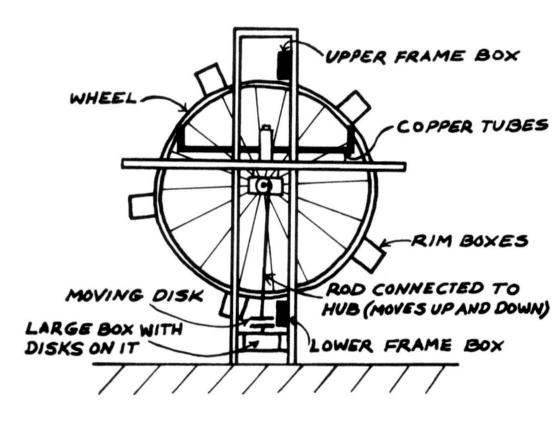

在投掷之前，音响师说：“我在机器附近的麦克风上发现了一些静电。” 这是一个暗示。

Before the toss, the sound guy said, "I'm getting some static on the mike near the machine." This was a hint.

麻省理工学院队赢得了抛掷，所以我们问了第一个问题。蒂姆问，或者更确切地说告诉琼斯博士，“如果我进入外太空，从太空舱中扔出一块岩石，它或多或少会永远保持其初始速度。但这不是永动机，因为岩石不会在其自身运动之外提供动力。你的机器不会在其自身运动之外提供动力，因此在第一类和第二类永动机的热力学定义中，你的设备会发生故障。”

Team MIT won the toss, so we asked the first question. Tim asked, or rather told, Dr. Jones, "If I go into outer space, and I throw a rock from a space capsule, it will keep going at its initial speed more or less forever. But that's not a perpetual motion machine, because the rock doesn't deliver power outside itself. Your machine doesn't deliver power outside its own motion, so in the thermodynamic definition of perpetual motion machines of the first and second kind, your device fails."

琼斯博士大吃一惊。西博格博士轻轻地上下点头。摄像机记录下了这一切。

Dr. Jones was taken aback. Dr. Seaborg nodded his head up and down slightly. The camera caught it all.

琼斯博士回答说：“事实仍然是，这台机器不断地移动。我挑战你来解释为什么。”

Dr. Jones answered, "The fact remains that this machine moves continually. I challenge you to define why."

“它多少钱？” 我问。如果我们对材料成本有上限，我们就可以消除推进方法，例如下部盒子中的微核反应堆或房间其他地方的发射器的微波接收器。

"How much did it cost?" I asked. If we had an upper bound on the materials cost, we could eliminate propulsive methods such as a micronuclear reactor in the lower box or a microwave receiver from a transmitter elsewhere in the room.

“我花了几百美元的设备和数百小时的劳动和烦恼，”琼斯博士的回答引起了演播室观众的笑声。

"A few hundred dollars in equipment and hundreds of hours of labor and aggravation on my part," Dr. Jones answered to laughter from the studio audience.

伯克利团队的麻省理工学院物理学家问道：“你连续运行它多久了？”

The MIT physics guy from Berkeley's team asked, "How long have you run it continually?"

“过去几个月，它在许多博物馆展出，展出时间长达三周，”他回答道。

"It's been on display in a number of museums over the past several months, for periods as long as three weeks," he answered.

我的自行车眼派上了用场。“车轮失灵是有原因的吗？” 我问。

My bicycling eye came in handy. "Is the wheel out of true for a reason?" I asked.

“不。这只是运输的压力，”琼斯博士说。

"No. It's just the stress of shipping," Dr. Jones said.

一位非麻省理工学院伯克利分校的人问道：“整个东西有多重？” 我想，这是多么愚蠢的问题啊。

One of the non-MIT Berkeley guys asked, "How much does the whole thing weigh?" What a stupid question, I thought.

“大约100磅。”

"About 100 pounds."

我们分手回各自的酒店房间。

We broke for our respective hotel rooms.

蒂姆开始了我们的讨论。“我认为他对我向他提出的第一个问题有点生气。如果我们要赢得这场比赛，我们就必须想出一个真正正确的解释。来自音响师的麦克风干扰是不过，黄金提示。其中一些盒子中一定存在电磁场相互作用。我们要一台晶体管收音机。当我还是个孩子的时候，我常常拿着我的晶体管收音机，在频道之间调谐，调高音量，然后把“它就在我父亲的立体声音响、冰箱背面、我母亲的吹风机旁边。它让我母亲发疯，但我可以通过收音机发出的噪音追踪空气中发生的事情。”

Tim started our discussion. "I think he was kind of ticked off at my first question to him. We're going to have to come up with an explanation that's really right if we're going to win this thing. That microphone interference from the sound guy was a golden hint, though. There must be some electromagnetic field interaction in some of those boxes. Let's ask for a transistor radio. When I was a kid I used to take my transistor radio, tune it between channels, turn up the volume, and put it next to things like my father's stereo, the back of the refrigerator, my mother's hair dryer. It drove my mother crazy, but I could sort of track what was happening in the air by the noise the radio made."

“好吧，”丹说。“我会把它写成我们想要的测试设备之一。那么管子呢？”

"OK," Dan said. "I'll write that as one of the items of test equipment we want. What about the tubes?"

“它们可能会吹向轮辋并提供足够的力来克服车轮轴承的摩擦，”我说。“我在比利时的一个朋友抽烟很多，我们用他的香烟来看看空气流动的情况，所以也许我们应该把香烟和火柴也列入清单。”

"They could be blowing on the rim and providing enough force to overcome the friction in the wheel's bearings," I said. "A friend of mine in Belgium smoked a lot and we used his cigarettes to see what air flow was doing, so maybe we should put cigarettes and matches down on the list, too."

“检查一下，”丹说。“我们首先对车轮进行功率分析。我们知道，在琼斯让机器连续工作之前，它需要大约半分钟的时间才能停止。这意味着当动力没有从任何地方转移到车轮的能量大约在30秒内就会耗散掉，我们可以计算出车轮运动时飞轮效应所储存的能量，除以30秒，就可以得出车轮运动所需功率的数量级。克服空气阻力和轴承的摩擦力。”

"Check," Dan said. "Let's first do a power analysis on the wheel. We know that before Jones made the machine work continuously, it took about half a minute for it to come to a stop. That means that when the power isn't being tranferred from wherever to the wheel, the energy of the wheel will be dissipated in about 30 seconds. We can calculate the energy stored in the flywheel effect of the movement of the wheel, and divide by 30 seconds, to find the order of magnitude of the power required to overcome the air resistance and the friction of the bearings."

好主意，我想。丹也曾在麻省理工学院读本科。他计算得很快，所需功率约为0.05瓦。一块或一组相当小的电池就可以让轮子运转几周。

Good idea, I thought. Dan had gone to MIT as an undergrad, too. He ran the calculation quickly, and the power requirement was about 0.05 of a watt. A fairly small battery or set of batteries would keep that wheel going for a few weeks.

“好的；0.05 瓦是克服摩擦力所需的功率。让我们看看从铜管中喷出的空气能否提供那么大的功率。Pepper，你是流体专家。你知道如何计算吗？” 丹问我。

"OK; 0.05 watt is the power required to overcome the friction. Let's figure out whether air jets coming out of the copper tubes could provide that much power. Pepper, you're the fluids whiz. Got any ideas how to calculate that?" Dan asked me.

“嗯，我知道如何计算从管子中流出的功率，以及这与从管子中流出的空气的速度有何关系。我会加入 10% 的效率系数；即十分之一从管道中喷出的空气射流的能量实际上可能会用来转动车轮。这是我们在接下来的一个小时内可以做出的最合理的假设。”

"Well, I know how to calculate how much power is coming out of the tubes, how that relates to the speed of the air coming out of the tubes. And I'll throw in a 10 percent efficiency factor; i.e., one-tenth of the energy of the air jet coming out of the tube might actually go into turning the wheel. That's as reasonable an assumption as any we can make in the next hour."

我写下了带有很多波浪形等号的方程，意思是“大约相等”；我在夏皮罗的课堂上学到了一些东西。“因此，这意味着空气喷射器要使车轮保持运转，空气速度必须约为每秒 3 英尺。如果我们在管子旁边放一根香烟，其余 90% 的空气应该能将烟雾吹得很漂亮。”明显地。”

I wrote down the equations with lots of wavy equals signs, meaning "approximately equal"; I'd learned something in Shapiro's class. "So that means that for the air jet to keep the wheel going, the air speed would have to be about 3 feet per second. If we put a cigarette next to the tube, the other 90 percent of the air should blow the smoke pretty visibly."

“那很好，”丹说。他在某种程度上扮演了我们团队领导者的角色，蒂姆是一个非常聪明的人，而我则很聪明并且有创造力。

"That's good," Dan said. He was sort of taking on the role of our team leader, with Tim the really smart guy, and me sort of smart and sort of creative.

“现在让我们考虑一下这件事可以转向的其他方式，”丹说。

"Now let's consider other ways this thing can turn," Dan said.

“我们需要确定是板驱动轮子还是轮子通过连杆驱动板，”我建议道。“要一个放大镜怎么样，我要仔细看看车轮上的连杆。如果车轮驱动连杆，连接销将位于其套筒顶部的套筒底部。行程，以及行程底部的套筒顶部。如果杆驱动轮，则情况相反。” 我从海伍德教授关于发动机轴承的讨论中学到了这个技巧。“我们需要一个放大镜，再加上聚光灯才能让我看到任何东西。”

"We need to determine whether the plates are driving the wheel or the wheel is driving the plates via the connecting rods," I suggested. "How about asking for a magnifying glass, and I'll get a good close look at the connecting rod at the wheel. If the wheel is driving the rod, the connecting pin will be on the bottom of its sleeve at the top of its stroke, and at the top of its sleeve at the bottom of the stroke. The opposite will be true if the rod is driving the wheel." I'd learned that trick from Professor Heywood's discussion of bearings in engines. "We'll need a magnifying glass, plus a spotlight for me to be able to see anything."

“听起来不错，”蒂姆说。“我们还应该检查这个东西是否从房间里的灯获得电力。框架上盒子上的那些小圆盘可能是太阳能电池。”

"Sounds good," Tim said. "We should also check out whether the thing gets any power from the lights in the room. Those little disks on the boxes on the frame could be solar cells."

我补充道，“是的，如果是这样的话，那么我们可以在给定的时间内计算轮子的转数，然后把房间里的灯关上一分钟左右，然后在同一时间内计算轮子的转数.如果它放慢速度，我们就会知道它是从房间里的灯获取能量的。”

I added, "Yeah, if that's how it works, then we can count revolutions of the wheel in a given time, then shut the lights out in the room for a minute or so, and then count revolutions of the wheel in the same time. If it slows down, we'll know that it's getting its power from the lights in the room."

丹回答道：“好吧，我们来做这个测试吧。不过，这有点明显；我的意思是，我打赌他把那些看起来像太阳能电池板的东西放在那里只是为了愚弄我们。但我们应该检查它的完整性。”

Dan answered, "Right, let's do that test. It's a little on the obvious side, though; I mean, I bet he put those solar-panellooking things on there just to fool us. But we should check it for completeness."

蒂姆说：“那么气流呢？也许它被放置在房间里，这样来自空调的空气在它的一侧上升，在另一侧下降。或者也许是来自房间热量的气流。” “明亮的灯光照射在边缘的盒子上，这样东西就会不断转动。这有点遥远，但是嘿，我们正在这里集思广益，不是吗？一个疯狂的想法可能会带来一个好的想法。”

Tim said, "What about air currents? Maybe it's placed in the room so that the air from the air-conditioning is going up on one side of it and down on the other side of it. Or maybe the air currents from the heat of the bright lights hit the boxes on the rim so that the thing keeps turning. It's sort of a long shot, but hey, we're brainstorming here, aren't we? One wild and crazy idea could lead to a good one."

“我们可以在这东西上面放一个大塑料袋，”我说。“如果他们让我们这样做，并且气流驱动它，那么它就会停止。我的意思是，这符合规则，对吧？我们不会碰它。除此之外，我们拿点冰、一根头发怎么样？吹风机和熨斗。我们可以移动冰块、吹风机和熨斗，这样我们就可以尝试打破稳定的气流，这种气流可能会以有序的方向推动盒子。我们可以引入一些熵系统就是这样。”

"We could put a big plastic bag over the thing," I said. "If they let us do that, and the air currents were driving it, it'd stop then. I mean that's within the rules, right? We wouldn't touch it. Barring that, how about we get some ice, a hair dryer, and an iron. We can move the ice and the hair dryer and the iron around so that we can try to break up the steady air flow that might be pushing the boxes around in such an orderly direction. We can introduce some entropy into the system that way."

“好吧，”丹说。“我会把‘大塑料袋’放在清单上。我们需要一些绳子来固定它，一些透明胶带来密封它，也许还需要一些橡皮筋只是为了更好地测量。还有其他我们应该做的事情吗？”求？”

"Okay," Dan said. "I'll put 'large plastic bag' on the list. We'll need some string to hold it up, and some scotch tape to seal it, and maybe some rubber bands just for good measure. Are there any other things we should ask for?"

“一把大锤子，”蒂姆说，“还有一份意大利辣香肠披萨。”

"A large hammer," Tim said, "and a pepperoni pizza."

“不过，说真的。我们还需要测试其他机制吗？” 丹问道。

"No seriously, though. Are there any other mechanisms we need to test?" Dan asked.

“如果下面的圆盘驱动这个东西，并且它们按照某种电容排斥原理运行——你知道，就像当你在毛衣上摩擦两个气球时它们会相互排斥——那么我们需要以某种方式进行测试。我不过，我不是物理学家，电磁理论就是原因，所以我不知道如何检查它，”我说。

"If the disks below are driving the thing, and they're running on some kind of capacitive repulsion principle-you know, like when you rub two balloons on your sweater and they repel each other-then we need to test that somehow. I'm not a physicist, though, and electromagnetic theory is why, so I don't know how to check that," I said.

蒂姆回答道：“我记得大一物理课《八点二》中的一些内容，内容是关于两个电容板之间的一块金属中的感应电流。如果这些板充当电容器，即它们存储电荷，那么我们放一块薄板两个极板之间的铜，随着电容器极板中的电荷量变化，铜的电荷量也应该变化，我们应该能够测量电流。”

Tim replied, "I remember something in freshman Physics, eight oh two, about an induced current in a piece of metal between two capacitive plates. If the plates are working as a capacitor- i.e., they store electric charges-and we put a sheet of copper in between the two plates, as the amount of charge varies in the plates of the capacitor, the amount of charge of the copper should vary, and we should be able to measure a current."

“很好，”丹回答道。“因此，对于该测试，我们需要一个环形支架来固定铜片，再加上一个电流表来看看我们是否可以测量任何电流。”

"Good," Dan answered. "So for that test we'll need a ring stand to hold the copper sheet, plus a current meter to see whether we can measure any current."

节目的制片人进来了，我们给了他我们的名单；丹从便笺簿上读到了这句话，而摄像机则捕捉到了他的侧面。

The show's producer entered and we gave him our list; Dan read it off the legal pad, while the camera caught him in profile.

“大约半小时内你就可以完成测试，”他说。“也许现在是你吃午饭的好时机。”

"You'll be able to do your testing in about half an hour," he said. "Maybe now would be a good time for you to get some lunch."

“这是个好主意，”我说。“您好，客房服务吗？请给我三个芝士汉堡和薯条。”

"That's a good idea," I said. "Hello, room service? Three cheeseburgers and fries, please."

当我们等待食物时，我们又聊了一些关于机器的事情，但蒂姆建议我们需要一些娱乐。

While we waited for the food, we chatted a little more about the machine, but then Tim suggested we needed some entertainment.

“你们想看《综合医院》还是《我们的日子》？”

"Would you guys rather watch 'General Hospital' or 'Days of Our Lives'?"

投票结果为“综合医院”，投票结果为二比一。

The vote was two to one for "General Hospital."

“汤姆？” 朱莉在屏幕上说道。“我必须告诉你一件事。我要离开你去找史蒂夫，你一起打高尔夫球的工程师。”

"Tom?" Julie said on the screen. "I have to tell you something. I'm leaving you for Steve, the engineer you play golf with."

“什么？” 汤姆回答道。“但我是一名律师。你能在他身上看到什么？”

"What?" Tom answered. "But I'm an attorney at law. What could you possibly see in him?"

“只是他看起来如此......如此......富有成效。”

"It's just that he seems so ... so ... productive."

音乐。消退。

Music. Fade Out.

我们完成了汉堡并进去测试机器。

We finished our burgers and went in to test the machine.

香烟测试，阴性。气流测试，阴性。熄灯测试，阴性。查看表格下方的电源线和电源测试，结果为阴性。用放大镜测试看轴承，没有结论。晶体管无线电测试，阳性！蒂姆扫描机器的方式就像《星际迷航》中麦考伊医生扫描病人一样，每当边缘上的小盒子越过框架上的盒子时，静电就会发出更大的嗡嗡声。

Cigarette test, negative. Air currents test, negative. Lights out test, negative. Look under the table for cord and power supply test, negative. Look at bearing with magnifying glass test, inconclusive. Transistor radio test, positive! Tim scanned the machine the way Doctor McCoy scans sick people on "Star Trek," and the static made a louder buzzing noise every time the little box on the rim went past the box on the frame.

我们没有时间在使用机器的四十五分钟内设置电流表。这必须在我们的第二次会议上讨论。

We didn't have time to set up the current meter in our fortyfive minutes with the machine. That would have to come in our second session.

我们回到房间讨论实验结果。

We went back to our room to discuss the results of our experiments.

“我们知道电力必须在框架上的上部盒子和边缘上的塑料盒之间传输，但是框架上的盒子如何知道何时打开和关闭？” 蒂姆问道。

"We know power must be transferred between the upper boxes on the frame and the plastic boxes on the rim, but how would the boxes on the frame know when to turn on and off?" Tim asked.

“也许机器底部的移动盘和固定盘之间的距离可以通过电力告诉底盒内的传感器车轮在循环中的位置，”我提议道。

"Maybe the distance between the moving disks and the fixed disks on the bottom of the machine electrically tells a sensor inside the bottom box where the wheel is in the cycle," I proposed.

“信息可以通过框架内的电线传输到框架上的上部盒子。该电线可以告诉上部框架盒子车轮在其周期中的位置。然后它可以打开电磁体来拉动轮圈磁铁，然后反转极性以将边缘磁铁推开。”

"The information could be transferred to the upper box on the frame through a wire inside the frame. That wire could tell the upper frame boxes where the wheel is in its cycle. It could then turn on an electromagnet to pull the rim magnet and then reverse polarity to push the rim magnet away."

“这是相当合理的，”蒂姆说，“但如果这些板块正在发挥作用呢？我们仍然需要对此进行测试。”

"That's fairly plausible," Tim said, "but what if the plates are doing the work? We still need to test that."

“我们可以在下次使用机器时做到这一点，”丹说。“不过，我也想知道下面那个盒子里装的是什么。对此你有什么想法吗？”

"We can do that in our next session with the machine," Dan said. "I'd like to know what's inside that lower box, though, too. Any ideas on that?"

“也许我们可以把听诊器放在离它很近的地方而不用碰它，”我说。“这样我也许能听到盒子里是否有任何机械动作。最坏的情况是，这可能会导致我在全国电视上拍出一张漂亮的头像。我可以把它发送给人才经纪公司。”

"Maybe we can put a stethoscope real close to it without touching it," I said. "I might be able to hear whether there's any mechanical action inside the box that way. At worst, it might result in a nice profile shot of me on nationwide TV. I could send it to a talent agency."

蒂姆回答说：“它可能不会告诉你任何事情，但可能值得一试。我们应该瞄准的主要目标是将那块金属放在板之间。任何人都知道如何将其连接起来？”

Tim answered, "It probably won't tell you anything, but it might be worth a try. The main thing we should aim for is to get that piece of metal in between the plates. Anybody got any ideas of how to hook it up?"

“它可能应该与电流表串联，”丹说。“不过，这有点毛茸茸的。自从我上二年级物理实验室以来已经很长时间了。”

"It should probably be in series with the ammeter," Dan said. "That's a little hairy, though. It's been a long time since I took sophomore physics lab."

“是的，如果他们为团队选择一个双 E 或物理学家而不是我们，那确实会有帮助。我的意思是，我们有点被我们领域的狭窄所困住了，”我说。

"Yeah, it would really help if they'd picked a double E or a physics guy for the team instead of one of us. I mean we're kind of trapped by the narrowness of our fields," I said.

丹画了一张如何将电流表连接到铜片上的草图。“我想我们已经准备好第二次拍摄了。现在会是什么？‘躁动的年轻人’？还是‘夜的边缘’？”

Dan drew a sketch of how to hook up the ammeter to the piece of copper. "I think we're ready for our second shot. What'll it be now? 'The Young and the Restless'? or 'The Edge of Night'?"

“我一直在关注《年轻人与不安分》，”蒂姆说。“我们可以看那个吗？”

"I've been following 'The Young and the Restless,' " Tim said. "Can we watch that?"

制片人在广告时段召集了我们。在我们返回房间进行第二轮测试之前，丹说：“等一下。我们在进去的路上必须做一些类似黑客的事情。”

The producer summoned us during a commercial break. Before we returned to the room for the second round of testing, Dan said, "Wait a minute. We've got to do something hacklike on our way in."

“一起吹口哨‘工作时吹口哨’怎么样？” 我建议。

"How about whistling 'Whistle While You Work' in unison?" I suggested.

“我喜欢这样，”蒂姆说。“我们先练习一下，然后再进去吧。”

"I like that," Tim said. "Let's practice first, then walk in."

我们做得很好——当我们从他身边呼啸而过时，摄影师微微一笑。后续测试没有任何结果。我通过听诊器没有听到任何声音，下板之间的环架上铜片上的电流表也没有告诉我们任何信息。丹站在机器旁边，看起来就像拉斯维加斯的轮盘赌庄家。不过，房间角落里的一堆测试设备确实告诉了我们一些事情。

We did pretty well-the cameraman smirked slightly as we whistled past him. Nothing came of the follow-up tests. I heard nothing through the stethoscope, and the ammeter on the copper sheet on the ring stand between the lower plates told us nothing either. Dan looked like a roulette dealer in Las Vegas as he stood next to the machine. The pile of test equipment in the comer of the room did tell us something, though.

示波器，许多看起来像电子设备的大盒子。神圣的主场优势，蝙蝠侠。伯克利大学的傻瓜们可能让整个物理和电气工程系的技术供应人员全天都处于高度戒备状态。由于这是因奥皮（J.罗伯特·奥本海默，原子弹开发者）而闻名的物理系，他们对复杂的非侵入式诊断工具的访问比我们多得多。也许我们应该早点来伯克利并与技术人员达成一些协议。

Oscilloscopes, many big electronicky-looking boxes. Holy home court advantage, Batman. The Berkeley dweebs probably had the whole physics and electrical engineering department technical supply staff on full alert for the day. And since this was the physics department made famous by Oppie (J. Robert Oppenheimer, A-bomb developer), their access to sophisticated nonintrusive diagnostic tools was far greater than ours. Maybe we should have come to Berkeley earlier and cut some deals with technicians.

回到我们的房间，伯克利在我们的门上贴了一张快乐的笑脸。我们同意，多么优雅啊。我们把一张皱着眉头的脸贴在他们的门上。

Back at our room Berkeley had taped a happy smiley face to our door. How declasse, we agreed. We taped a frowny face to their door.

“那么我们要说什么，伙计们，谁来说呢？” 丹问道。

"So what are we going to say, guys, and who's going to say it?" Dan asked.

“蒂姆是个聪明人。他应该这么做，”我说。“丹，你和我都穿红色衣服，所以我们获得了十五秒的成名。”

"Tim's the smart one. He should do it," I said. "Dan, you and I've both worn red so we've gotten our fifteen seconds of fame."

“蒂姆，你愿意吗？” 丹问道。

"Are you willing, Tim?" Dan asked.

“当然，为什么不呢？让我们想想我们要说什么，”蒂姆实事求是地说。他有教授的潜质。

"Sure, why not. Let's figure out what we're going to say," Tim said matter-of-factly. He had professor potential.

我说：“让我们把我们确定知道的事情列出来。当我在论文工作中遇到机械问题时，我实验室的技术人员尼克总是告诉我要做的事情。”

I said, "Let's make a list of what we know for sure. That's what Nick the technician in my lab has always told me to do when I'm stuck on a mechanical problem in my thesis work."

“好吧，”蒂姆说。当我们讨论时，丹写下了这份清单。

"OK," Tim said. Dan wrote the list as we talked through it.

1. 框架上的盒子具有能量传递，经晶体管无线电测试证明。

1. Upper boxes on frames have energy transfer, proved by transistor radio test.

2. 冰/吹风机测试证明，房间内的气流没有任何作用。

2. Air currents in room aren't doing anything, as proved by ice/hairdryer test.

3. 熄灯测试证明，上层盒子上的假光电管没有任何作用。

3. Fake photocells on upper boxes aren't doing anything, as proved by lights-out test.

4. 喷气管只是一个诡计，香烟测试证明了这一点。

4. Air jet tubes are just a ruse, as proved by cigarette test.

5. 所有电源都必须独立于机器中的电池中，如插头测试表所示。

5. All power has to be self-contained in machine in batteries somewhere, as proved by look under table for plug test.

6、经听诊器测试，下箱无较大噪音。

6. No major noise comes out of the lower box, as proved by stethoscope test.

7. 通过铜测试证明，没有大电流传入和传出板。

7. No large current is being conveyed to and from plates, as proved by copper test.

当我们完成清单时，蒂姆说：“所以我们知道能量从边缘上的盒子传递到框架上的盒子。不过，我们仍然困惑于框架上的盒子如何知道如何打开和关闭。”在正确的时间拉动车轮。我的意思是，如果他搞砸了，框架上的盒子可能会在应该推动轮辋上的盒子时拉动轮辋上的盒子，而在应该拉动轮子时推动它，并且事情不会再继续下去了。”

When we finished our list, Tim said, "So we know the energy's going from the boxes on the rim to the boxes on the frame. We're still stuck, though, on how the boxes on the frame know how to turn on and off themselves at the right time to pull the wheel around. I mean, if he messed it up, the box on the frame could pull the box on the rim when it's supposed to push it and push it when it's supposed to pull it, and the thing wouldn't keep going."

“这可能就是今天早上发生的事情，当时它无法启动，”我提出。“我仍然认为它可能与下面的活塞同步。板每转上下移动的次数与轮辋上的塑料盒经过框架上的盒子的次数之间有一个设定的比率。也许盒子里面有一个电路，它从板的运动中获取脉冲，并告诉电磁体何时打开和关闭。机器内部可能有电线以电子方式传送该信息。

"That might be what was happening this morning when it wouldn't start," I offered. "I still think it might be synchronized with the pistons below. There's a set ratio between the number of times the plates go up and down per revolution and the number of times the plastic boxes on the rim go by the boxes on the frame. Maybe there's a circuit inside the box that takes a pulse from the motion of the plates and tells the electromagnet when to turn on and off. There could be wires inside the machine that convey that information electronically."

“对我来说听起来不错，”蒂姆说。

"Sounds good to me," Tim said.

“我也是，”丹说。

"Me, too," Dan said.

制片人敲了敲门。我们三个人回到房间，蒂姆做了解释，而丹和我坐在后台，对镜头显得很热心和警惕。然后我们走出房间，经过伯克利分校的同学们进来。这位麻省理工学院物理学专业的本科生在前面带路，脸上挂着傲慢的笑容。麻省理工学院团队遇到了麻烦。伯克利把那张皱着眉头的脸重新贴在了我们的门上。

The producer knocked on the door. The three of us returned to the room and Tim presented the explanation, while Dan and I looked keen and alert for the camera as we sat in the background. Then we went out of the room and passed the Berkeley guys on their way in. The MIT undergrad physics major led the way, with a cocky, arrogant grin on his face. Team MIT was in trouble. Berkeley had put the frowny face back on our door.

在“比赛游戏”进行到一半时，制片人回来让我们坐下来听大卫·琼斯博士的判断，看看谁对这件事是如何运作的有更好的解释。我的胃里和胸口再次有了那种感觉，那种空虚的感觉，就像你在等待知道你的考试成绩、你的 SAT 分数是多少、哪些大学录取了你时的感觉。

Midway through "The Match Game," the producer came back to have us sit down and listen to Dr. David Jones's judgment on who had the better explanation of how the thing worked. I had that feeling in my stomach and my chest again, that hollow feeling you get when you're waiting to find out how you did on a test, what your SAT scores were, which colleges accepted you.

“两个团队都表明这不是永动机。虽然两个团队都将主要推进装置放在边缘塑料盒中的磁铁和框架上的电磁体中，但伯克利团队更正确地解释了如何机器工作正常，因为他们正确地将整个控制装置与框架上的盒子中包含的脉冲电磁体隔离开来。麻省理工学院的团队错误地将连接到轮子侧面的杆暗示为某种“控制”机构。”

"Both of the teams have shown that this is not a perpetual motion machine. While both teams located the primary means of propulsion in the magnets in the plastic boxes on the rim and the electromagnets on the frame, the Berkeley team more correctly explained how the machine works, because they correctly isolated the entire control to a pulsed electromagnet contained in the box on the frame. The MIT team incorrectly implicated the rods attached to the side of the wheel, as some kind of 'control' mechanism."

琼斯博士从镜框上取下盒子，打开一个放相机的盒子。“正如你所看到的，里面有一个小电池，和一些简单的电子电路，为电磁铁的打开和关闭提供定时。”

Dr. Jones removed the boxes from the frame and opened one for the camera. "As you can see, there is a small battery inside, and some simple electronic circuitry to provide the timing for the electromagnet to turn on and off."

坝。对不起大家。对不起麻省理工学院。如果我们当中只有一个人懂得一些电子产品就好了。我真的应该上一两节课；这是现在的浪潮。

Dam. Sorry guys. Sorry MIT. If only one of us knew some electronics. I really should take a class or two in that; it's the wave of the present.

琼斯博士继续说道。“然而，你注意到，一旦我取下电磁盒，机器仍在转动。你看，有一个单独的推进机制，两个团队在他们的解释中都没有提到。” 他的笑容与来自伯克利的物理学家一样傲慢、自大。演播室的观众对着镜头尽职尽责地大笑。我们尽职尽责地与获胜者、他的同事以及机器的发明者握手。

Dr. Jones continued. "You notice, however, that once I've taken off the electromagnet boxes, the machine is still turning. You see, there is a separate propulsive mechanism that neither team addressed in their explanation." He smirked the same arrogant, cocky smirk that the physics guy from Berkeley smirked. The studio audience laughed dutifully for the camera. We dutifully shook hands with the winner and his colleagues and the inventor of the machine.

之后丹和我坐在酒店泳池边的按摩浴缸里。蒂姆顺便过来，坐在池畔的躺椅上。客房服务送来了茶点——我们仍然在报销。

Afterward Dan and I sat in the Jacuzzi by the pool at the hotel. Tim dropped by and sat in the poolside lounge chair. Room service brought the refreshments-we were still on expense account.

“你知道，我们真的让研究所失望了；我的意思是，我对此感到非常难过，”我说。

"You know, we've really let the institute down; I mean, I feel really bad about it," I said.

“是的，我也是，”丹说。“你能递一下鱼子酱吗？”

"Yeah, me too," Dan said. "Could you pass the caviar?"

“我们很接近，”蒂姆说。“太接近了。佩珀和我最近才接管了控制权，这太糟糕了；如果我们没有这样做，也许我们就不会试图在机器中找到控制器。而且你知道还有什么，当我们试图识别工作时我认为我们在另一种推进方法上走在正确的轨道上。我认为这是某种电容装置，其中电极性变为正极性和负极性，因此在周期的某个时刻它正在拉动“当它把另一块板推离它时，我们发现了这一点；如果我们了解更多关于电力和电气测试的知识，我们就可以证明这一点。”

"We were close," Tim said. "Damn close. It's too bad Pepper and I took controls so recently; if we hadn't, maybe we wouldn't have tried to find a controller in the machine. And you know what else, when we tried to identify the work the plates were doing, I think we were on the right track for the other method of propulsion. I think it was some kind of capacitive device, where the electric polarity went positive and negative, so that at one point in the cycle it was pulling the plate toward it, while it was pushing the other plate away from it. We caught that; if only we knew more about electricity and electrical testing we could have proven it."

“是的，”丹说。“不过，让我感到困惑的是，他们团队中唯一有头脑、能说话的人就是那个天体物理学家。其他人似乎只是顺水推舟。”

"Yeah," Dan said. "The thing that gets me, though, is that the only guy from their team who had any brains, who did any of the talking, was that astrophysics guy. The other guys seemed to be just going along for the ride."

蒂姆补充道，“他在麻省理工学院完成了本科学业。难怪他这么优秀。”

Tim added, "And he did his undergraduate work at MIT. No wonder he was so good."

“是的，”我说。“三名麻省理工学院的工程师与一名麻省理工学院的物理学家。忘记伯克利吧；这不是一场公平的竞争。”

"Yeah," I said. "Three MIT engineers versus one MIT physicist. Forget Berkeley; it wasn't a fair contest."

# 章节

# C H A P T E R

# 15

# 15

# Hackito Ergo Sum

# Hackito Ergo Sum

日程：

Schedule:

83 年春季：2.01 固体力学（希尔）

Spring '83: 2.01 Mechanics of Solids (Hill)

2.94 固体动力学（林肯）

2.94 Dynamics of Solids (Lincoln)

2.996 论文

2.996 Thesis

2月14日

February 14

希尔教授庄严地站在固体力学课前。我后面一排有一张空桌子。“我有一些非常悲伤的消息告诉你。你的一位同学昨天结束了自己的生命。”

Professor Hill solemnly stood before the solid mechanics class. There was an empty desk in the row behind me. "I've got some very sad news for you. One of your classmates took his own life yesterday."

我当时就想哭，但我和班上所有十九、二十岁的孩子们一起忍住了。他为什么这么做？这个地方为何会产生绝望、孤独和无力的感觉，将任何人推向崩溃的边缘？我记得史蒂夫·沃森的经历；他真的很聪明，但他仍然觉得自己一文不值。我记得第一个学期，看门人埃迪告诉我要放松，时不时地玩玩，这样他就不必打电话给校园警察来剪断床单、绳子或皮带，并进行口对口人工呼吸。 。

I wanted to cry right then and there, but I suppressed it along with all the nineteen- and twenty-year-olds in the class. Why did he do it? What is it about this place that breeds the feeling of hopelessness, loneliness, and inadequacy that could push anyone over the edge? I remembered the Steve Watson experience; he was really smart and he still felt worthless. I remembered Eddy the janitor telling me to take it easy that first term, to have fun now and then so he wouldn't have to call the campus police to cut the sheet or the rope or the belt and issue mouth-to-mouth resuscitation.

希尔教授是一位善良而温和的人，每当我去他的办公室寻求帮助时，他都会耐心地回答我的问题。他继续着演讲的悲伤前奏。“求你了。如果你不高兴，就别闹到这种程度。来跟我谈谈，或者和你的宿舍导师、或者“夜线”、或者宗教顾问、或者精神科，或者如果你有的话，请告诉朋友。不要忘记你有一个选择。你可以离开研究所。这不是世界上唯一好的工程学校。事实上，如果你去其他没有教授的地方在如此大的研究经费压力下，你可能会接受更好的教育。如果你在这方面需要任何帮助，请与我联系。”

Professor Hill was a kind and gentle man, who patiently an swered my questions whenever I went to his office for help. He continued the sad prelude to the lecture. "Please. If you're unhappy, don't let it go that far. Come and talk to me, or talk to your hall tutor, or to "Nightline," or to a religious counselor, or to the psychiatric department, or to a friend if you have one. And don't forget one option that you have. You can leave the institute. It's not the only good engineering school in the world. In fact, if you go somewhere else where the professors aren't under such pressure to produce research funding you might receive a better education. Please talk to me if you need any help along these lines."

我报名参加了希尔教授的静力学课程和林肯教授的本科生动力学课程，二九四。静力学是梁、桁架、桥梁之类的东西。动力学是指移动的横梁、桁架和桥梁，它们在风中前后摇晃。动力学也是车床、机器人手臂和导弹轨迹。

I enrolled in Professor Hill's class, a.k.a. Statics, and Professor Lincoln's undergraduate Dynamics class, two nine four. Statics is beams and trusses and bridges and things like that. Dynamics is beams and trusses and bridges that move, that rock back and forth in the wind. Dynamics is also lathes and robot arms and missile trajectories.

两七十分后，我知道在与本科生的正面竞争中，可以取得 A 的成绩。我认为这两门课程会让我的成绩单上再多加两个 A。这些课程将是我对博士资格考试力学部分的复习。在麻省理工学院，你必须寻找多弹头导弹的方法，一石多鸟。

After two seventy I knew that A's were attainable in head to head competition with the undergrads. I figured the two courses would add two more A's to my transcript. And the classes would be my review for the mechanics section of the doctoral qualifying exams. At MIT you have to look for ways to MIRV things, to kill multiple birds with one stone.

3月10日

March 10

在牢房里。Chet 和我准备使用新的启动装置在高压下进行 RCM 点火。

In the cell. Chet and I prepared for the RCM firing at high pressure with the new starting mechanism.

“我希望你也安装喷油器，”他说。“我们可能还无法制作电影，但如果我们燃烧燃料，我们将有一些数据向联盟展示。”

"And I want you to mount the fuel injector, too," he said. "We may not be able to make a movie yet, but if we combust fuel we'll have some data to show the consortium."

“但是，切特，如果实验出了问题怎么办？为什么我们不关闭喷油器，我用一块有机玻璃封闭气缸？里面已经有 0 环和所有东西了，”我反驳道。“如果一切顺利，我们可以在注射器就位的情况下进行第二次点火。”

"But, Chet, what if something goes wrong with the experiment? Why don't we leave the fuel injector off and I'll close the cylinder with a piece of Plexiglas? It's got the 0-rings in it already and everything," I countered. "If everything goes well, we can do a second firing with the injector in place."

“我认为这样做是浪费时间，但如果你坚持的话，我们可以这么做。”

"I think it's a waste of time to do that, but if you insist, we can do that."

我的脉搏频率没有像以前那样升高。压力的增加是可以预见的；我知道在多大的压力下，金属会发出自我调整的沉闷声。

My pulse rate didn't rise quite as high as it had on previous firings. The pressure buildup was predictable; I knew at what pressures the clunks of the metal adjusting itself would occur.

繁荣。

BOOOM.

嘶嘶声。成功射击后我释放了油箱的压力。我又开始正常呼吸了。切特和我走到机器前面，海伍德教授打开牢房的门，看看测试进行得如何。

Hisssss. I dumped the pressure from the tank after the successful firing. I breathed regularly again. Chet and I went to the front of the machine, and Professor Heywood opened the door to the cell to see how the test went.

在我的坚持下，我们安装的没有燃油喷射器的窗户被打碎了。活塞由更高的压力、更高的力和更高的动量驱动，遵循的不是切特的计算机模型，而是牛顿和墨菲定律。活塞的预定目的地距离窗户大约一英寸；它的实际目的地是在窗户的中间。如果燃油喷射器就位，它就会被毁坏。

The window we put in at my insistence, without the fuel injector, was shattered. The piston, driven by the higher pressure and the higher force and the higher momentum, had obeyed not Chet's computer model, but Newton's and Murphy's laws. The piston's intended destination was about an inch short of the window; its actual destination was halfway through the window. Had the fuel injector been in place it would have been destroyed.

“我猜你是对的，”切特对我说。

"I guess you were right on that one," Chet said to me.

“这会让我们有点倒退，”海伍德教授说。“我们可以修理设备。我很高兴你们俩都安然无恙。去年，广岛工业学院水口分校的 RCM 爆炸，导致两名研究生丧生。”

"This will set us back a bit," Professor Heywood said. "We can fix the equipment. I'm glad both of you are all right. Mizugachi at the Hiroshima Institute of Technology lost two graduate students last year when their RCM exploded."

“教授，迷路了吗？” 我问。

"Lost, Professor?" I asked.

“半栋大楼都跟着他们走了。”

"Half the building went with them."

感谢您与我分享这一点，教授。

Thank you for sharing that with me, Professor.

1983 年 4 月 4 日

April 4, 1983

十五年前的今天，在孟菲斯，詹姆斯·厄尔·雷 (James Earl Ray) 将牧师马丁·路德·金 (Martin Luther King, Jr.) 定位在他的高威力步枪瞄准镜的十字准线中，并扣动了扳机。十五年前的今天，林肯教授坐在我的办公桌前，和我一样二十五岁。十五年前的今天，他比现在更属于少数派，因为他获得了一个又一个的A，并开始走上终身教职的道路。他有一个梦想。

Fifteen years ago today, in Memphis, James Earl Ray located the Reverend Martin Luther King, Jr., in the cross hairs of the scope of his high-powered rifle and pulled the trigger. Fifteen years ago today, Professor Lincoln sat in my desk and was twenty-five like me. Fifteen years ago today he was more of a minority than he is now, as he received A after A and started on the path to tenure. He had a dream.

林肯教授站在教室前面讲台上的桌子上，略高于地面。他的西装使他成为《花花公子》杂志 1980 年 12 名最佳着装男士之一。他的咨询费为他带来的不是一辆而是两辆白色捷豹 12 缸 XJ6 四门汽车，配有全皮革内饰和 Bose ('5 1) 扬声器。

Professor Lincoln stood at the front of the room on the table on the lecture platform slightly above floor level. His suits qualified him to be one of Playboy magazine's twelve best-dressed men of 1980. His consulting fees netted him not one but two white Jaguar 12-cylinder XJ6 four-doors with full leather interiors and Bose ('5 1) speakers.

他把上一讲的话题讲完了。“因此，当输入到系统的能量频率与您按下系统时系统来回摆动的频率相同时，就会发生共振。看，这有点像当您还是个坐在秋千上的孩子时”。

He finished the topic of the previous lecture. "And so resonance occurs when the frequency of energy input into a system is the same as the frequency that the system would rock back and forth if you gave it one push. See, it's sort of like when you were a child on a swing set."

他画了一套秋千，旁边有一些希腊字母。

He sketched a swing set with some Greek letters next to it.

他继续说道，“现在，当你还是个秋千上的孩子时，你就像一个钟摆。你的母亲或父亲是一个强迫函数。如果他们把你举起来，让你在不推的情况下摆动，你就会每四秒左右来回摆动一次。 。这就是你的固有频率，或者有些人称之为共振频率，每四秒一次。现在，当你还是个孩子的时候，你就知道在秋千上最有趣的部分就是越荡越高。事情发生的方式是这样的妈妈或爸爸每隔四秒左右就会推你一下，他们在正确的时间以正确的速度向你输入正确的能量，让你越走越高。

He continued, "Now you as a child on the swing set were a pendulum. Your mother or father was a forcing function. If they held you up and let you swing without pushing, you would swing back and forth once every four seconds or so. That's your natural frequency, or what some people call your resonant frequency, once per four seconds. Now as a child you knew that the fun part of being on the swing set was to swing higher and higher. And the way that happened was that Mommy or Daddy gave you a push every four seconds or so, and the energy they input into you was in the right direction at the right time at the right speed to make you go higher and higher.

“在工程学中，你的问题通常是避免这些共振频率。例如，如果你是一座桥，风使你身上的气压以共振频率变化，你很快就会摇晃。这种情况已经发生过好几次了在过去的一两个世纪里。另一方面，如果你成为一名乐器设计师，你的任务将是设计总是能产生共鸣的系统。但这就足够了。你们都放下铅笔，好吗？剩下的在讲座中我不会谈论动力学。”

"In engineering, your problem will usually be to avoid these resonant frequencies. For example, if you were a bridge, and the wind made the air pressure on you vary at a resonant frequency, you'd soon shake apart. That's happened several times in the past century or two. On the other hand, if you become a musical instrument designer, your task will be to design systems that always resonate. But that's enough on resonance. Y'all put down your pencils, OK? For the rest of the lecture I'm not going to talk about dynamics."

班上的其他人收起了笔记本和便笺本。林肯呈现出不同的性格。

The rest of the class put away their notebooks and pads. Lincoln assumed a different character.

“你看，啊，我要上大学了。每一天，在啊进来给你们讲课之前，看到你们的白人教员，他们让我失望，在啊出来和你们谈话之前，他们向我介绍了六个小时”全部。”

"Y'see, Ah nevah wint tah college. Everuh day, before Ah come in tuh lecture y'all, the seenyuh white faculty, dey sets me down, and dey briefs me foe six houwuhs befoe ah comes out to talks to y'all."

除了二月份离开希尔教授的班级、研究所和地球的那一位之外，八十名班级里发出了一两声笑声，气氛有些紧张。

There was a chuckle or two, and sort of a tense air in the class of eighty minus the one who left Professor Hill's class and the institute and Earth in February.

“不过，说真的，”他继续说道。“麻省理工学院是一个种族主义、性别歧视的机构。你可能会问自己，‘为什么不应该如此；这个国家的所有其他机构也是如此，这意味着世界上的机构’，但这不是重点。你现在在这里，并且我想给你们举一些例子来说明我想要表达的观点。”

"But seriously, though," he continued. "MIT is a racist, sexist institution. You may ask yourselves, 'Why shouldn't it be; so is every other institution in this country, that means in the world,' but that's not the point. You are here now, and I want to give you some examples of the point I'm trying to make."

笑声消失了，取而代之的是冰冷的沉默。

The chuckles disappeared and were replaced by stone cold silence.

“我已经给你举了如何解拉格朗日方程的例子。当我和你年纪相仿时，我选修了物理系的这门课程，也选修了电气工程系的这门课，无论是本科生还是大学。研究生水平。我什至在数学系选修了两门课程，这些课程构成了这些材料的基础。在大三和大四之间的暑假里，当我白天、晚上和周末为我的一位教授做研究时，我做了每件事“我提出了自己的问题并做了它们。我想彻底掌握如何在现实世界中应用这些方程的每一个方面、每一个方面、每一个微妙之处、每一个特殊情况。”

"I've given you examples of how to solve Lagrange's equations. When I was about your age, I took the Physics department's equivalents of this class, and I took the Electrical Engineering department's equivalents of this class, in both cases at the undergraduate and graduate level. I even took two classes in the Mathematics department that formed the underpinnings of the material. During the summer between junior and senior year when I did research for one of my professors during the day, at night and on weekends, I did every problem I put my hands on. I made up my own problems and did them. I wanted to thoroughly master every aspect, every facet, every subtlety, every special case of how to apply these equations in the real world."

他停了下来。“我把这个项目一直持续到圣诞节前，课程结束后，当我完成后，我想与某人分享它。我把这本书拿给我的导师看，他说，‘你做了什么？ “刚才所做的就是将方程简化为一组机械求解过程。这根本没有什么特别的。二十年后，一台愚蠢的计算机将能够做你所做的事情。” 我问你，如果我像你们大多数人一样是个宅男，你认为他会那样回应吗？”

He paused. "I kept up the project to just before Christmas time, just after the end of classes, and when I was done, I wanted to share it with someone. I showed the book to my adviser, and he said, 'What you've just done is trivialize the equations to a set of mechanical solution procedures. There's nothing special to that at all. In twenty years a dumb computer will be able to do what you've done.' I ask you, do you think he would have responded that way if I were a homeboy like most of you?"

不，我想。他的顾问一定听过肖克利（Ph.D. '36）关于黑人在基因上较差的说法。种族主义科学家占据了他们神奇的权力地位，并且凭借他们比我们其他人更聪明的事实，他们告诉我们谎言，而我们几乎无力辩论，更不用说反驳了。

No, I thought. His adviser must have heard Shockley's (Ph.D. '36) allegation that blacks are genetically inferior. Racist scientists take their wizardly positions of power, and by virtue of the fact that they're smarter than the rest of us, they tell us lies that we are nearly powerless to debate, much less disprove.

林肯继续说道：“所以我拿着那个笔记本活页夹，那是我在两年多的夜晚和周末准备的，我去了高级住宅院子里的篝火旁，我把它扔在那里，看着它燃烧。当我哭的时候。所以你必须制作自己的笔记本并亲自开创这些解决方案。”

Lincoln continued, "So I took that notebook binder, that one that I'd prepared during more than two years of nights and weekends, and I went to the bonfire in the Senior House courtyard, and I threw it in there and watched it burn while I cried. So you will have to make your own notebooks and pioneer those solutions yourselves."

然后他直视着我的眼睛，有那么一瞬间很不舒服。

Then he looked at me, straight in the eye, for an uncomfortable second.

“现在，我想给你们举一个最近的例子。几周前，我向你们讲授了机电系统中的磁链。你们中的一个人用‘难倒教授’的语气问了一个问题，这表明你正在寻找报复的机会，而且由于我是黑人，你认为我可能很容易被击中。你们中的一个人要求我推导出等式的电气方面，我们机械工程师不会推导的方面通常不会记住。但即使我烧掉了笔记本，我也已经内化了知识，而且你可能还记得，我提出了一个完整的、正确的推导。”

"Now, I'd like to give you a more recent example. A few weeks ago, I lectured to you about flux linkage in an electromechanical system. One of you asked a question in that 'stump the professor' tone of voice, the kind that shows you're looking for a chance to get even, and since I'm black you thought I might be an easy hit. One of you asked me to derive the electrical side of the equation, the side that we mechanical engineers wouldn't normally have committed to memory. But even though I burned my notebook, I had internalized the knowledge, and as you may recall, I presented a complete, correct derivation."

我低头看着地板，将肘部放在桌子上，手放在额头上，以避免进一步的目光接触。他在谈论我。

I looked down at the floor, put my elbow on the desk and my hand across my forehead so as to avoid any further eye contact. He was talking about me.

“我并不是要求你们所有人改变世界。我只是要求你们考虑是否有可能放弃偏见，”他补充道。“现在天气真好，剩下的课时间大家都出去散散步吧，下个雨天我们就可以补讲义材料了。”

"I'm not asking you all to change the world. I'm just asking you to consider the possibility of laying aside your prejudices," he added. "Now, it's a beautiful day. Why don't you all go out and take a walk for the rest of the class time. We can make up the lecture material on the next rainy day."

4月20日

April 20

“嘿，佩珀，我想和你谈谈一些事情，”埃尔登·提利尔说道，一边用手指在我公寓门旁边的墙上敲打着打字的动作。埃尔登是阿特金森学院的新生之一，他住在我的楼下。我们都迷恋辛迪，他制作了精美的声音效果，例如，带有消音器的机关枪以及卢克·天行者和达斯·维德在星球大战中决斗的嗡嗡声虚拟剑。我第一次见到他是在迎新周期间，两个大三学生试图把他赶出房间。

"Hey, Pepper, I want to talk to you about something," Eldon Tyrell said, drumming his fingers in a typing motion on the wall next to the door to my apartment. Eldon was one of the Atkinson freshmen, who lived down the hall from me. We both had a crush on Cindy, and he did fine vocal sound effects of, for example, a machine gun with a silencer on it and the buzzing virtual swords that Luke Skywalker and Darth Vader dueled with in Star Wars. I'd first met him when two juniors were trying to bully him out of his room during orientation week.

埃尔登主修航空航天，涉及流体力学，这是我的强项，我们成了朋友——足够好的朋友，我向他吐露了我的文学抱负。他成为了这方面的盟友、线人。

Eldon was an aero-astro major, which involved fluid mechanics, my forte, and we'd become friends-good enough friends that I'd confided my literary ambitions to him. He became an ally on that front, an informant.

“当然，孩子，进来吧，”我用鲍嘉最好的声音说道。

"Sure, kid, come on in," I said in my best Bogart voice.

他坐在我桌子一端旁边的椅子上，就像客户在私家侦探办公室里坐的椅子一样，是一把黑色的木制研究所发行的办公椅，而我则坐在绿色的带有脚轮的诺加海德扶手转椅上，把脚放在上面。放在桌子上。

He sat in the chair next to the end of my desk, like the chair the client sits in in the private eye's office, a black wooden instituteissue desk chair, and I sat back in the green Naugahyde arm-swivelchair on casters and put my feet up on the desk.

"Sho, whadaya got to shay, kid?" I asked him.

“等一下，灯光不对，”他回答道。“我们需要你从传热实验室办公室里拿出来的装饰艺术台灯，让它指向远离我们之间桌子的角落，这样我们就一半在明亮的光线下，一半在阴影中。在那里。让我把灯关掉头顶上的灯。这更符合气氛。”

"Wait a minute, the lighting's not right," he answered. "We need the art deco desk lamp you swiped from your office in the heat transfer lab sort of pointing away from the corner of the desk between us so we're half in bright light, half in shadow. There. And let me turn off the overhead light. That fits the mood much better."

“嘘，谢伊怎么了，孩子？” 我在第二次问他。

"Sho, whadaya got to shay, kid?" I asked him in take two.

“来，让我给你看这个。我刚刚被录取了。我终于进入了 THA。太神奇了；我真的很兴奋。他们昨天才告诉我。来，看看这个。”

"Here, let me show you this. I was just accepted. I'm finally in THA. It's so amazing; I'm really psyched. They just let me know yesterday. Here, look at this."

他在桌子上明亮的地方放了一张纸。信笺顶部印有“鹰之下”字样，信笺抬头还饰有秃鹰的左翼和头部。左边距垂直写着“限制”，下边距用小字写着“出于安全原因，请勿向宿舍中的其他任何人展示此内容。技术黑客协会”。

He put a sheet of paper on the desk in the bright part. At the top of the sheet was printed "Under the Eagle," and the left wing and head of a bald eagle completed the letterhead. The left margin said vertically, "Restricted," and the bottom margin said in fine print, "For security reasons, do not show this to anyone else in your dormitory. The Technology Hackers Association."

高质量的印刷文本有几项公告。“沿着运动场旁边的阿默斯特巷行驶的巴士即将遭到黑客攻击。用手术管水气球攻击肮脏的野兽；请不要使用肥皂——我们不想激怒巴士公司……粉红色水气球的可能性向示威者扔东西……毕业典礼上的《不可能的黑客》；德克斯在 HY 游戏中用气球把我们挖了出来。《不可能的黑客》一定很棒。”

The high-quality printed text had several announcements. "Coming Hack on the buses that drive down Amherst Alley next to athletic field. Attack the dirty beasts with surgical tubing water balloons; no soap, please-we don't want to anger the bus company.... Possibility of pink water balloon throw at demonstrators. ... Impossible Hack at graduation; the Dekes scooped us with the balloon at the H-Y game. Impossible Hack must be good."

我问埃尔登，不可能的黑客计划是什么。

I asked Eldon what the impossible Hack plan was.

“我不能透露细节；我的意思是，我已经告诉你这么多了，我应该开枪射杀你。这么说吧，我们将击败西德特勤局的安全扫荡。看，赫尔穆特·施密特，前西德人校长，计划在大约一个月后的毕业典礼上发表讲话。我们正在计划进行一次黑客攻击，这将使其中一些人失去工作。但这并不容易。我们正在与他们的子孙打交道盖世太保，这些人都很好。但我认为我们能做到。我的意思是，我们的父母和祖父母赢得了战争，不是吗？

"I can't divulge details; I mean, I'm already telling you so much I should shoot you. Let's just say we're going to defeat the West German Secret Service security sweep. See, Helmut Schmidt, the former West German chancellor, is scheduled to speak at graduation in about a month. We're planning a hack that's going to cost a few of those guys their jobs. It's not going to be easy, though. We're dealing with the sons and grandsons of the Gestapo, and these guys are good. But I think we're up to it. I mean, our parents and grandparents won the war, didn't they?"

“是的。” 我不再是鲍嘉，又开始做我自己。我把脚从桌子上移开，靠在椅子上。“那粉红色的水气球呢？”

"Yeah." I stopped being Bogart, started being myself again. I took my feet off the desk and leaned forward in the chair. "What about the pink water balloons?"

“好吧，我对此并不太自豪。其中一些人确实是法西斯分子。我的意思是，我不同意他们所做的一切。你知道麻省理工学院是如何收购 Simplex 拥有的所有土地的，以及他们如何“我们将拆除所有这些出租单元，让许多贫困的剑桥港居民无家可归，然后他们将建造研发办公空间，当他们完成时，这些办公空间可能只是增加了平方英尺到那时波士顿市场可能会出现日益严重的办公空间供过于求的情况吗？” 他反问道。

"Well, that one I'm not too proud of. Some of these guys are really fascists. I mean, I don't agree with everything they do. You know how MIT has acquired all that land owned by Simplex, and how they're going to tear down all those rental units and make a whole lot of poor Cambridgeport residents homeless, and then they're going to build R&D office space that by the time they're through will probably be just an addition of square footage to a growing office space glut that will probably occur in the Boston market by then?" he asked rhetorically.

“是的，”我回答。

"Yes," I answered.

“好吧，THA 高层想从他们示威地点附近的建筑物屋顶向他们扔粉红色的水气球，”他说。“我不太确定这是一个好主意。示威者可能会认为麻省理工学院让我们这样做，然后他们会更加讨厌这个研究所。我的意思是，这就是那些扭曲的、偏执的左派人士看待事物的方式。”

"Well, the THA brass wants to throw pink water balloons at them from the roofs of the buildings near where they're demonstrating," he said. "I'm not so sure it's a good idea. The demonstrators will probably figure MIT put us up to it and then they'll hate the institute even more. I mean that's how those warped, paranoid leftists look at things."

“也许随着你在组织中的进步，你可以从内部改变它，”我说。“但除此之外，请告诉我更多关于你参与的事情。申请程序是什么？”

"Maybe as you advance in the organization you can change it from within," I said. "But aside from that, tell me more about your involvement. What was the application procedure?"

我给了他一杯冰水后，他主动提出接听。

He offered to answer after I gave him a glass of ice water.

“这些人组织得非常好，”他说。“他们给了我这张表格；我的意思是一份打印的表格，就像你填写工作申请一样，比如政府或其他什么的。它询问了各种个人问题，比如我在其中做过哪些黑客行为。高中，我的政治信念是什么，还有很多其他个人问题，我不想让组织之外的任何人看到的事情。这有点像耶鲁大学的骷髅会。不同之处在于，你必须聪明地进入THA，你必须是地主贵族才能进入骷髅会。无论如何，我签署了申请，所以他们抓住了我。例如，如果他们发现我违反了保密誓言，他们都会‘我所要做的就是将我的申请表发送给我的雇主，然后我就会沉没。”

"These guys are incredibly organized," he said. "They gave me this form; I mean a printed form, just like you'd fill out for a job application, like for the government or something. It asked all kinds of personal questions, like what kinds of hacks I'd done in high school, what my political convictions were, and a lot of other personal questions, things I wouldn't want anyone outside the organization to see. It's sort of like Skull and Bones at Yale. The difference is that you have to be smart to get into THA, and you have to be a landed gentry blueblood to get into Skull and Bones. Anyway, I signed the application, so they've got me. If they find out I violated the confidentiality oath, for example, all they'll have to do is send my application form to my employer, and I'll be sunk."

“别担心，我会给你改名字的。”我说。“这次行动听起来就像我读到的有关情报组织的内容。”

"Don't worry, I'll change your name," I said. "The operation sounds like what I've read about intelligence organizations."

“你最好相信这一点，”埃尔登回答道。“他们有部门领导什么的。甚至还有情报部长。他们有关于看门人何时打扫教室以及警察巡查的情况的文件。这样他们就知道如何制造转移注意力。如果他们进行黑客攻击时，一支队伍将在远离 CP 活动范围的区域创建一个转移点。X 名 CP 将调查该转移点，并且必须撬开或闯入的门将不会发热。部长“情报人员还会收集其他随机信息；他会监听谈话，诸如此类的事情。这有点恶心，但真的很有趣。我可以喜欢在某人的房子里安装窃听器或窃听某人的电话。”

"You better believe it," Eldon answered. "They've got section heads and everything. There's even a minister of intelligence. They have files on when the janitors clean the classrooms and what the rounds of the CPs are. That way they know how to create a diversion. If they're going to do a hack, one team will create a diversion in an area away from the CPs' beat. X number of CPs will investigate the diversion, and the door that has to be picked or broken into will be free of heat. The minister of intelligence also goes around collecting other random information; he listens in on conversations, things like that. It's kind of sick but it's really fun. I could enjoy putting bugs into someone's house or tapping someone's phone."

“然后剥夺一些你努力保护的自由？” 我问。

"And take away some of the freedom you're working to protect?" I asked.

“听着，没关系。如果你发现的只是丈夫不忠，而妻子却不知道，那又怎样。你不会用这些信息做任何事情。这是森林里的老树倒下。”不是一个好主意。我真的可以从中得到乐趣。不过我永远不会杀任何人。但是天哪，我可能在中央情报局的职业生涯中，五年后我可能会杀人，我不相信那。”

"Look. It doesn't matter. So what if all you find out is that the husband is being unfaithful and the wife doesn't know it. You won't do anything with that information. It's the old tree falling in the forest not making a sound idea. I could really have fun with this. I'd never kill anyone though. But gosh, I'm probably on a CIA career track and in five years I might be killing people and I don't believe in that."

我回答说：“别担心。你不会杀死任何人。至少不会直接杀人，”我说。

I responded, "Don't worry about it. You won't kill anyone. Not directly anyway," I said.

“直接或间接，我不喜欢它。这违背了我的宗教信仰。不过，我认为你是对的。他们可能会分包所有的打击。我很确定从THA到中央情报局有一条管道，就像“骷髅会就是这样。例如，我们有 OSS 开锁指南。战略服务办公室……他们是中央情报局的前身。”

"Directly or indirectly, I don't like it. It's against my religion. I think you're right, though. They probably subcontract all the hits. I'm pretty sure there is a pipeline from THA to the CIA, just like there is with Skull and Bones. For example, we have the OSS guide to lockpicking. The Office of Strategic Services ... they were the precursor of the CIA."

“是的，但现在这是一份公开文件。你可能可以从国家技术信息服务处订购它，”我反驳道。

"Yeah, but that's a public document by now. You can probably order it from the National Technical Information Service," I countered.

“不管怎样。不过，你应该看看它。它有各种各样的技巧。看，撬锁的蛮力方法就是把他们称之为耙子的东西放进去。但耙子的问题是，你可以将光照射到钥匙孔中并判断锁是否被撬开。所以还有另一个带有钩子的小工具。”

"Whatever. You should see it, though. It has all kinds of tricks in it. See, the brute force way to pick a lock is to put this thing they call a rake into it. But the problem with the rake is that you can shine a light into the keyhole and tell whether the lock has been picked. So there's this other little tool with a hook in it."

他从口袋里掏出钥匙链，给我看了一小块金属，看起来有点像瑞士军刀的开罐器。

He took his keychain out of his pocket and showed me a short piece of metal that looked sort of like a can opener from a Swiss army knife.

埃尔登继续解释。“你一次只选取一个别针，没有人对此一无所知。一些资深的中央情报局人员可以在十五秒内选取七个别针。它是选取，拉动，转动手柄，选取，拉动，转动手柄，直到你宾果游戏在。”

Eldon continued the explanation. "You just pick one pin at a time, and no one knows anything about it. Some veteran CIA guys can pick seven pins in fifteen seconds. It's pick, pull, turn handle, pick, pull, turn handle, until bingo you're in."

“CP们不觉得你们很烦吗？” 我问。

"Don't the CPs find you guys annoying?" I asked.

“不是真的。根据我们的宪法，我们不能造成任何破坏。有一次，有一群人闯入绿色大楼的顶部，偷走了空袭警报器。CP们以为这是THA，但实际上是一些哭泣兄弟会男孩们。THA 开始执行一项小任务，并于第二天返回警报器，并附有一张纸条，上面写着“THA 提供”。另外，对于门和锁，我们绝不会用钳子或虎钳进行攻击。如果黑客需要拆除整个门把手，然后重新组装，我们就会这么做。这就是我们的运作方式。”

"Not really. It's in our constitution that we can't do any damage. One time some group broke into the top of the Green Building and stole the air raid warning sirens. The CPs thought it was THA, but it was actually some sniveling frat boys. THA embarked on a little mission and returned the sirens the next day, with a note saying, 'Courtesy THA.' Plus, with doors and locks, we never attack them with pliers or vice grips. If the hack requires removing an entire door handle and then reassembling it later, that's what we'll do. That's just the way we operate."

“你已经破解了吗？”

"Have you hacked yet?"

“是的。前几天我刚刚执行任务。我们破解了图书馆的圆顶。这真是太神奇了。我们在会议室会面，回顾了我们所有的任务以及我们将发送和接收的信号以了解这一点海岸没有危险。我们同步了手表，然后当我们沿着走廊行走时，领队在几个地方看到拐角处有一只匿名的手作为信号，我的意思是时机恰到好处。我们继续前进，爬到了圆顶顶部，在那里野餐。太棒了，我的意思是凌晨三点查尔斯河以及整个剑桥和麻省理工学院的景色。这是一个入门黑客。我不知道哪一个圆顶黑客攻击更难，他们在上面放了一个电话亭，当警察上去检查时，或者当我们把一头活牛放在那里时，电话就会响。”

"Yeah. I just went on a mission the other day. We hacked the dome in the library. It was just so amazing. We met in a conference room and reviewed all our tasks and what signals we'd send and receive to know that the coast was clear. We synchronized our watches and then when we were walking down the corridor the group leader saw just an anonymous hand around a corner as a signal at a couple of places, I mean with perfect timing. We went ahead and climbed to the top of the dome and had sort of a picnic up there. It was awesome, I mean what a view at three in the morning of the Charles and all of Cambridge and MIT. It was a starter hack. I don't know which dome hack was tougher, the one when they put a phone booth up there and the phone rang when the CPs went up to check it out, or when we put a live cow up there."